# DATA608 | Knowledge and Visual Analytics

Gabriella Martinez

8/29/2022

# Module 1: Exploratory Data Analysis

```r
library(dplyr)
library(reactable)
library(ggplot2)
library(forcats)
```

**Principles of Data Visualization and Introduction to ggplot2**

I have provided you with data about the 5,000 fastest growing companies in the US, as compiled by Inc. magazine. lets read this in:

```r
inc <- read.csv("https://raw.githubusercontent.com/charleyferrari/CUNY_DATA_608/master/module1/Data/inc5000_data.csv", header= TRUE)
```

And lets preview this data:

```r
head(inc)
```

```
##   Rank                         Name Growth_Rate   Revenue
## 1    1                         Fuhu      421.48 1.179e+08
## 2    2        FederalConference.com      248.31 4.960e+07
## 3    3                The HCI Group      245.45 2.550e+07
## 4    4                      Bridger      233.08 1.900e+09
## 5    5                       DataXu      213.37 8.700e+07
## 6    6 MileStone Community Builders      179.38 4.570e+07
##                       Industry Employees         City State
## 1 Consumer Products & Services       104   El Segundo    CA
## 2          Government Services        51     Dumfries    VA
## 3                       Health       132 Jacksonville    FL
## 4                       Energy        50      Addison    TX
## 5      Advertising & Marketing       220       Boston    MA
## 6                  Real Estate        63       Austin    TX
```

```r
summary(inc)
```

```
##       Rank          Name            Growth_Rate         Revenue
##  Min.   :   1   Length:5001        Min.   :  0.340   Min.   :2.000e+06
##  1st Qu.:1252   Class :character   1st Qu.:  0.770   1st Qu.:5.100e+06
##  Median :2502   Mode  :character   Median :  1.420   Median :1.090e+07
##  Mean   :2502                      Mean   :  4.612   Mean   :4.822e+07
##  3rd Qu.:3751                      3rd Qu.:  3.290   3rd Qu.:2.860e+07
##  Max.   :5000                      Max.   :421.480   Max.   :1.010e+10
##
##    Industry           Employees           City              State
##  Length:5001        Min.   :    1.0   Length:5001        Length:5001
##  Class :character   1st Qu.:   25.0   Class :character   Class :character
##  Mode  :character   Median :   53.0   Mode  :character   Mode  :character
##                     Mean   :  232.7
##                     3rd Qu.:  132.0
##                     Max.   :66803.0
##                     NA's   :12
```

Think a bit on what these summaries mean. Use the space below to add some more relevant non-visual exploratory information you think helps you understand this data:

First, I’d like to take a look at the structure of the table using the `str()` function. It looks like we have 5001 observations and 8 variables, two of which are integer type, four being character type, and two numerical type.

```r
# Insert your code here, create more chunks as necessary
str(inc)
```

```
## 'data.frame':    5001 obs. of  8 variables:
##  $ Rank       : int  1 2 3 4 5 6 7 8 9 10 ...
##  $ Name       : chr  "Fuhu" "FederalConference.com" "The HCI Group" "Bridger" ...
##  $ Growth_Rate: num  421 248 245 233 213 ...
##  $ Revenue    : num  1.18e+08 4.96e+07 2.55e+07 1.90e+09 8.70e+07 ...
##  $ Industry   : chr  "Consumer Products & Services" "Government Services" "Health" "Energy" ...
##  $ Employees  : int  104 51 132 50 220 63 27 75 97 15 ...
##  $ City       : chr  "El Segundo" "Dumfries" "Jacksonville" "Addison" ...
##  $ State      : chr  "CA" "VA" "FL" "TX" ...
```

The number of companies for each state is checked by aggregating the data by state. A few things to notice from the output is that there are 52 states. Puerto Rico (PR) and Washington D.C. (DC) have been included as states.

Additionally, sorting the table in descending order, it is seen that California is the state with the highest number of growing companies with a whopping 701 companies, followed by Texas with 387, and New York with 311. Toggling the `Count` column, the states with the least number of growing companies can also be noted. Puerto Rico is at the bottom of the list with 1 company, followed by Alaska with 2, and West Virginia, also with 2.

```r
state <- inc %>%
  select(State, City) %>%
  group_by(State) %>%
  summarise(Count = length(State)) %>%
  arrange(desc(Count)) %>%
  reactable(bordered = TRUE, striped = TRUE,
          highlight = TRUE, filterable = TRUE,  showPageSizeOptions = TRUE,
          showPagination = TRUE, pageSizeOptions = c(5, 10, 20),
          defaultPageSize = 5)

state
```

| State | Count |
| --- | --- |
| CA | 701 |
| TX | 387 |
| NY | 311 |
| VA | 283 |
| FL | 282 |
| IL | 273 |
| GA | 212 |
| OH | 186 |
| MA | 182 |
| PA | 164 |

[output cut: 42 more lines]

In a similar fashion to above, the table is grouped by `Industry` this time to see the number of growing companies in each industry. The data is then sorted by the `Count` of the total number of growing companies. The top three industries are IT Services with 733, Business Products & Services with 482, and Advertising & Marketing with 471 companies. At the bottom are Computer Hardware with 44, Insurance with 50, and Environmental Services with 51 companies.

```r
ind <- inc %>%
  select(Industry, State) %>%
  group_by(Industry) %>%
  summarise(Count = length(Industry)) %>%
  arrange(desc(Count)) %>%
  reactable(bordered = TRUE, striped = TRUE,
          highlight = TRUE, filterable = TRUE,  showPageSizeOptions = TRUE,
          showPagination = TRUE, pageSizeOptions = c(5, 10, 25),
          defaultPageSize = 5)

ind
```

| Industry | Count |
| --- | --- |
| IT Services | 733 |
| Business Products & Services | 482 |
| Advertising & Marketing | 471 |
| Health | 355 |
| Software | 342 |
| Financial Services | 260 |
| Manufacturing | 256 |
| Consumer Products & Services | 203 |
| Retail | 203 |
| Government Services | 202 |

[output cut: 15 more lines]

Below the total revenue for each industry is listed. In our previous table, it looks like IT Services have the highest number of growing companies with 733 companies, but the highest amount of revenue (26.4 billion dollars) is coming from the Business Products & Services industry where there are 482 companies.

```r
revenue <- inc %>%
  select(Industry, Revenue) %>%
  group_by(Industry) %>%
  summarise(Total_Revenue = sum(Revenue)) %>%
  arrange(desc(Total_Revenue))


#revenue


reactable(revenue, columns = list(
  Total_Revenue =
    colDef(format = colFormat(prefix = "$", separators = TRUE, digits = 2))),
    bordered = TRUE, striped = TRUE,
    highlight = TRUE, filterable = TRUE,  showPageSizeOptions = TRUE,
    showPagination = TRUE, pageSizeOptions = c(5, 10, 25),
    defaultPageSize = 5)
```

| Industry | Total_Revenue |
| --- | --- |
| Business Products & Services | 26367900000 |
| IT Services | 20681300000 |
| Health | 17863400000 |
| Consumer Products & Services | 14956400000 |
| Logistics & Transportation | 14840500000 |
| Energy | 13771600000 |
| Construction | 13174300000 |
| Financial Services | 13150900000 |
| Food & Beverage | 12911300000 |
| Manufacturing | 12684000000 |

[output cut: 15 more lines]

Below is a table with the State, Industry, and Total Revenue corresponding to each combination. At the very top is Illinois’ Computer Hardware industry with a total revenue of approximately 10.3 billion dollars, followed by Texas’ Energy Industry with an approximate total revenue of 7.8 billion dollars.

```r
inc %>%
  select(State, Industry, Revenue) %>%
  group_by(State, Industry) %>%
  summarise(Total_Revenue = sum(Revenue)) %>%
  arrange(desc(Total_Revenue)) %>%
  reactable(columns = list(
  Total_Revenue =
    colDef(format = colFormat(prefix = "$", separators = TRUE, digits = 2))),
    bordered = TRUE, striped = TRUE,
    highlight = TRUE, filterable = TRUE,  showPageSizeOptions = TRUE,
    showPagination = TRUE, pageSizeOptions = c(5, 10, 25),
    defaultPageSize = 10)
```

| State | Industry | Total_Revenue |
| --- | --- | --- |
| IL | Computer Hardware | 10261300000 |
| TX | Energy | 7800800000 |
| IL | Food & Beverage | 6244500000 |
| IL | Business Products & Services | 5733100000 |
| WI | Construction | 4847200000 |
| NY | IT Services | 4826200000 |
| NY | Consumer Products & Services | 4799300000 |
| VA | Government Services | 3822300000 |
| NC | Consumer Products & Services | 3507100000 |
| CA | Financial Services | 3444200000 |

[output cut: 788 more lines]

## Question 1

Create a graph that shows the distribution of companies in the dataset by State (ie how many are in each state). There are a lot of States, so consider which axis you should use. This visualization is ultimately going to be consumed on a ‘portrait’ oriented screen (ie taller than wide), which should further guide your layout choices.

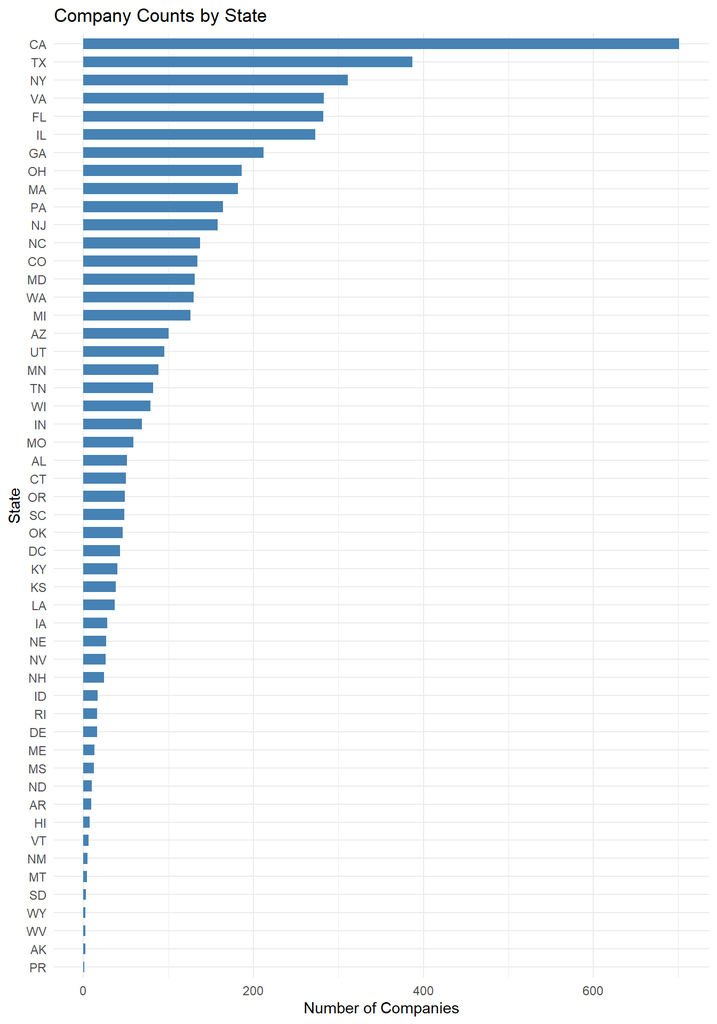

```r
# Answer Question 1 here
inc %>%
  group_by(State) %>%
  summarise(Count = length(State)) %>%
  ggplot(aes(x=fct_reorder(factor(State),Count),
             y= Count))+
  geom_col(width = 0.6, position = position_dodge(0.9), fill= "steelblue") +
  #geom_text(aes(label = Count, vjust = 1.2))+
  coord_flip()+
  labs(title= "Company Counts by State",
       x= "State", y = "Number of Companies")+
  theme_minimal()
```

## Quesiton 2

Lets dig in on the state with the 3rd most companies in the data set. Imagine you work for the state and are interested in how many people are employed by companies in different industries. Create a plot that shows the average and/or median employment by industry for companies in this state (only use cases with full data, use R’s `complete.cases()` function.) In addition to this, your graph should show how variable the ranges are, and you should deal with outliers.

Below is a boxplot of the employment data by industry where the black dot added in is the mean[^1] of the data. The graph below contains the outliers of about 6 of variables which visibly skews the graph making it difficult to make out the distributions of the other variables.

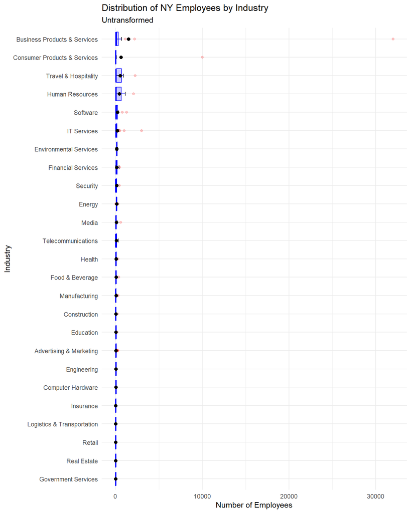

```r
# Answer Question 2 here

#complete cases df and State filter for NY
inc_NY <- inc[complete.cases(inc), ] %>%
  filter(State == 'NY')

inc_NY  %>%
  ggplot(aes(x=reorder(Industry, Employees), y=Employees))+
  stat_boxplot(geom = "errorbar", width = 0.2) +
  geom_boxplot(outlier.colour = "red", color="blue", fill="blue", alpha=0.2)+
  stat_summary(fun=mean, geom="point", shape=20, size=3, color="black",
               fill="black") +
  coord_flip() +
  labs(title = "Distribution of NY Employees by Industry",
       subtitle = "Untransformed",
       x = "Industry", y="Number of Employees") +
  theme_minimal()
```

Next is a graph where the extreme outliers have been removed using the `boxplot.stats()`[^2] function. Removing the outliers provides a better display of the data however it eliminates data points of possible importance.

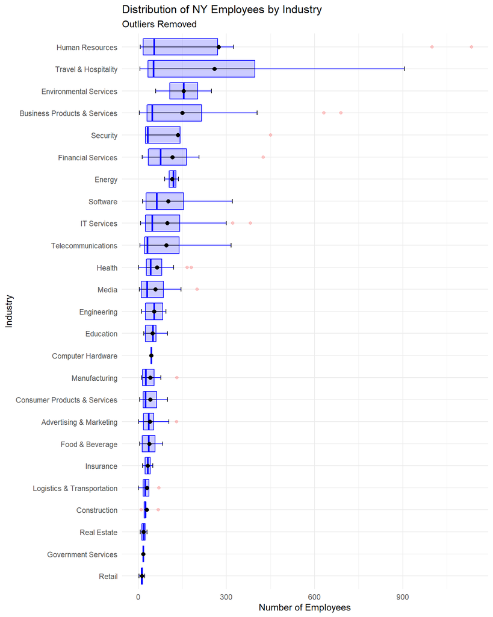

```r
inc_NY2 <- inc_NY %>%
  group_by(Industry) %>%
  filter(!Employees %in% boxplot.stats(Employees)$out) %>%
  ungroup

inc_NY2 %>%
  ggplot(aes(x=reorder(Industry, Employees), y=Employees))+
  stat_boxplot(geom = "errorbar", width = 0.2) +
  geom_boxplot(outlier.colour = "red", color="blue", fill="blue", alpha=0.2) +
  stat_summary(fun=mean, geom="point", shape=20, size=3, color="black",
               fill="black") +
  coord_flip() +
  labs(title = "Distribution of NY Employees by Industry",
       subtitle = "Outliers Removed",
       x = "Industry", y="Number of Employees") +
  theme_minimal()
```

Alternatively, a log scale can be added to the visualization using `scale_y_log10()`[^3] in ggplot2 to reduce the impact of the outliers on the plot without the need of removing them from the data.

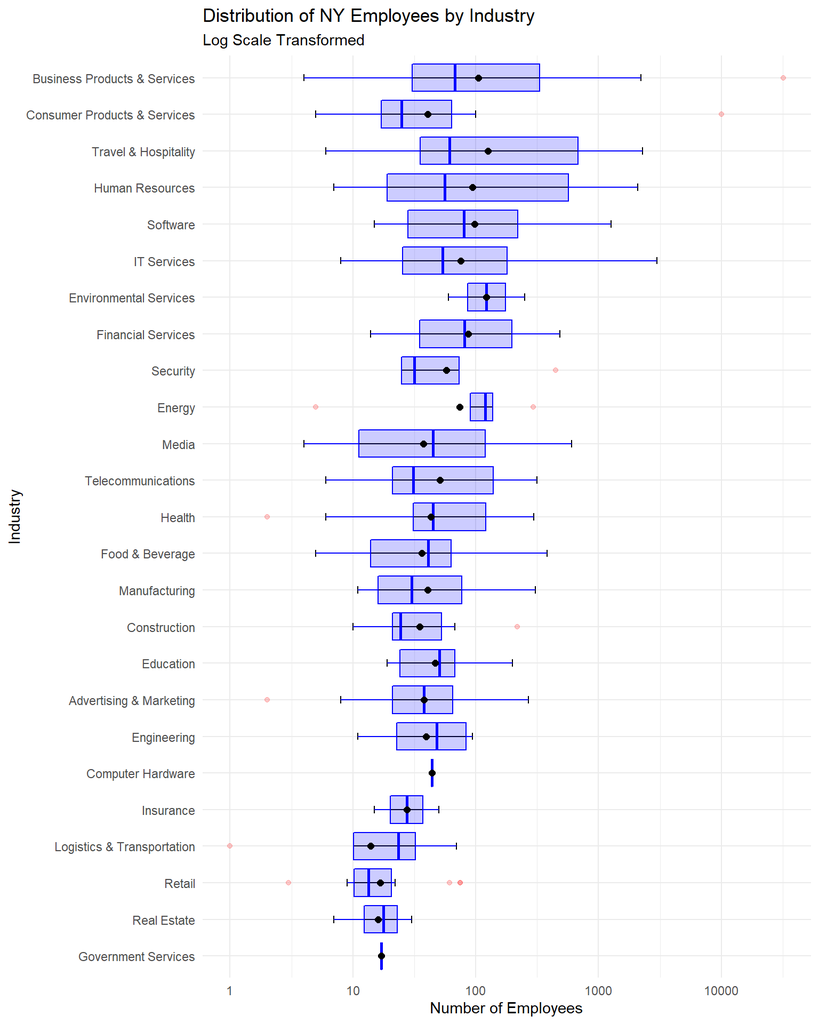

```r
inc_NY  %>%
  ggplot(aes(x=reorder(Industry, Employees), y=Employees))+
  stat_boxplot(geom = "errorbar", width = 0.2) +
  geom_boxplot(outlier.colour = "red", color="blue", fill="blue", alpha=0.2)+
  stat_summary(fun=mean, geom="point", shape=20, size=3, color="black",
               fill="black") +
  coord_flip() +
  scale_y_log10() +
  labs(title = "Distribution of NY Employees by Industry",
       subtitle = "Log Scale Transformed",
       x = "Industry", y="Number of Employees") +
  theme_minimal()
```